# Use of Elsevier Journals by Domain

UVA StatLab/RDS

## Use by Domain

Use of a provider’s journal differs by research domain. The following figures show the use – all article downloads in 2017, current year article downloads in 2017, UVA references, and UVA-authored publications – by research domain as provided in the 1figr data. Note that this captures the assigned research domain of the article, not of the researcher downloading, referencing, or publishing.

### 7a. All Article Downloads by Domain

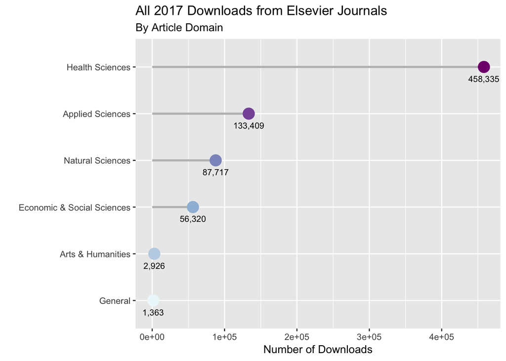

The vast majority of use of Elsevier titles at UVA, whether measured by downloads, citations, or publications, is of articles from the health sciences. For all articles downloaded from Elsevier in 2017, 61.9% are of articles in the health science domain.

### 7b. Current Year Article Downloads by Domain

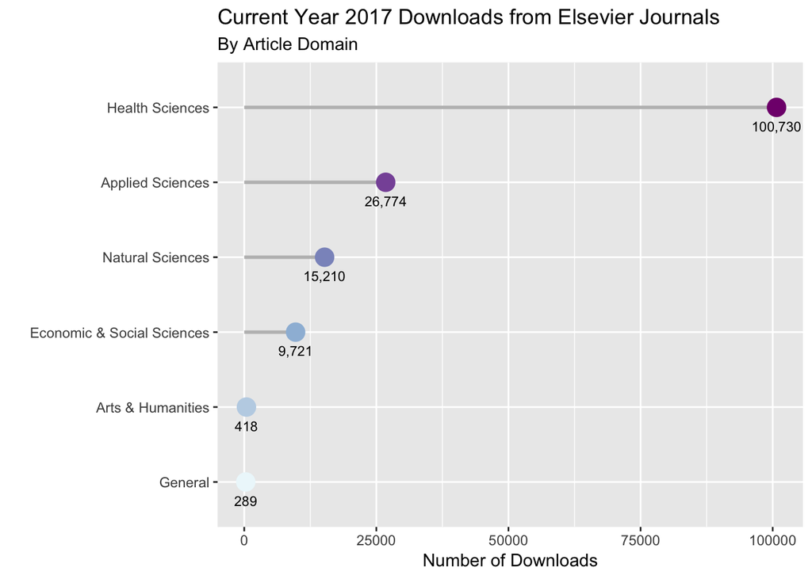

For current year articles downloaded by UVA researchers from Elsevier in 2017, 65.8% are of articles in the health science domain.

### 7c. UVA References by Domain

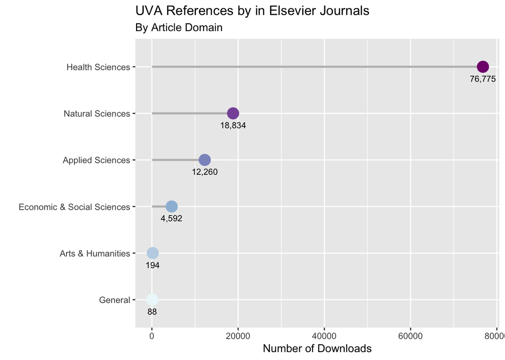

For references made to articles in Elsevier journals by UVA authors from 2008 to 2017, 68.1% are made to articles in the health science domain.

### 7d. UVA-Authored Publications by Domain

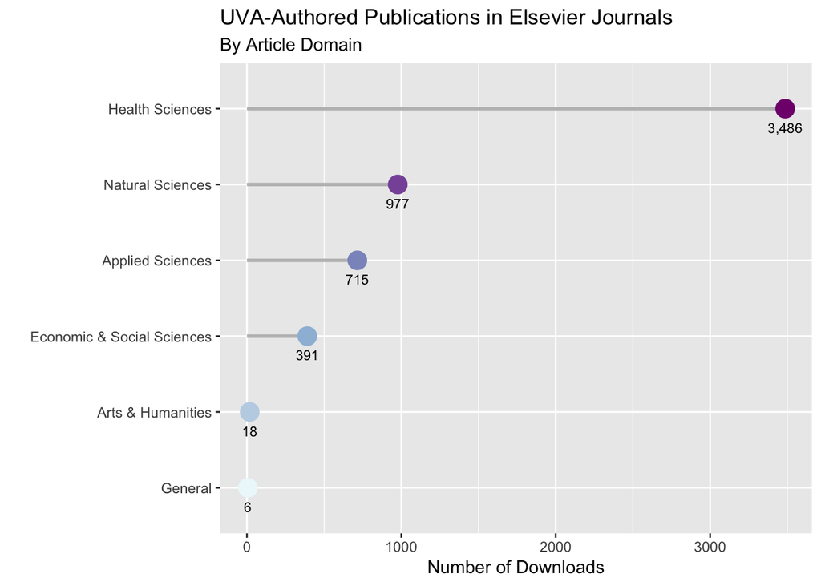

For articles published in Elsevier journals from 2008 to 2017 by UVA authors, 62.3% are made to articles in the health science domain.